# 1-Analysis based on Views,Likes,Dislikes,Comment Count

# 3. Dislikes - Comment Count Scatter Plot

```python
def scatter_dc(select,country):
    plt.scatter(select['dislikes'],select['comment_count'])
    plt.xlabel('Dislikes')
    plt.ylabel('Comment Count')
    plt.title('Dislikes - Comment Count Scatter Plot for ' + country,fontsize=20)
    plt.show()
```

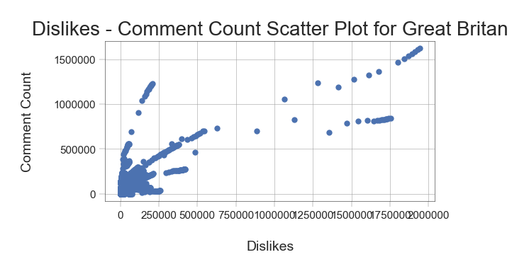

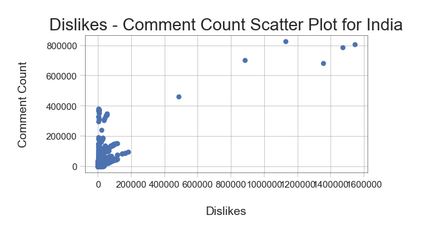

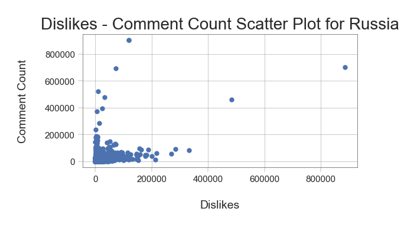

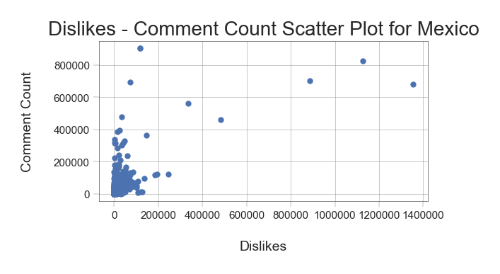

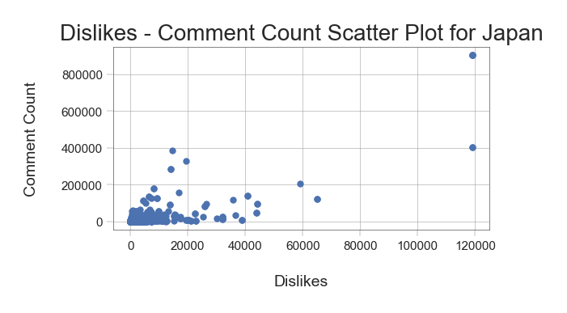

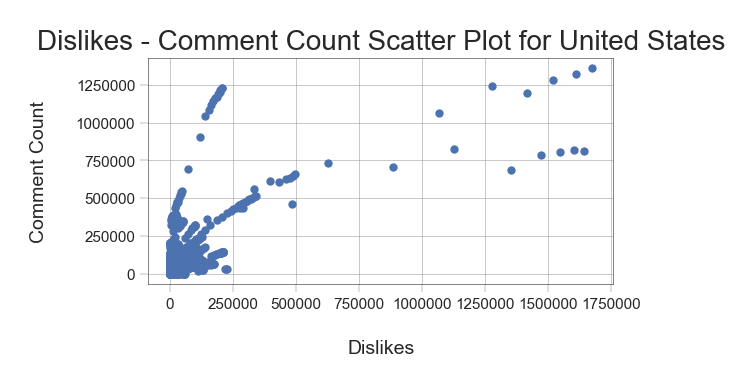

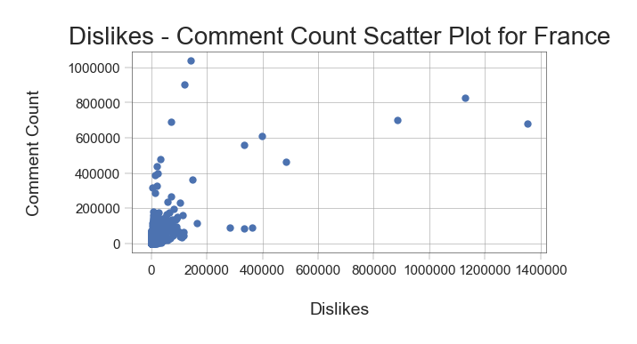

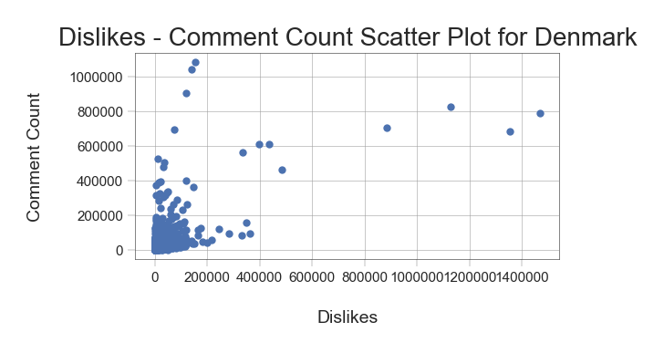

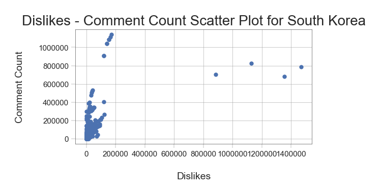

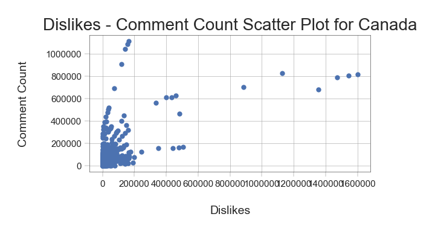

```python
for i in countries:
    select = df.loc[data['region']==i] #Selects all rows of a particular country
    scatter_dc(select,i)
```

# Comparison of ratios ( country-wise )

```python
df = df[(df != 0).all(1)]
df = df.reset_index(drop=True)
```

```python
df.describe()
```

|  | views | likes | dislikes | comment_count |
| --- | --- | --- | --- | --- |
| count | 358399.00 | 358399.00 | 358399.00 | 358399.00 |
| mean | 1364654.35 | 39574.72 | 2208.23 | 4450.33 |
| std | 7229389.19 | 169191.02 | 23015.16 | 26056.72 |
| min | 117.00 | 1.00 | 1.00 | 1.00 |
| 25% | 51082.00 | 816.00 | 48.00 | 135.00 |
| 50% | 187286.00 | 3870.00 | 195.00 | 567.00 |
| 75% | 673138.50 | 18739.00 | 791.00 | 2157.00 |
| max | 424538912.00 | 5613827.00 | 1944971.00 | 1626501.00 |

```python
ratio_df = pd.DataFrame(columns = ['likes/views' , 'dislikes/views' , 'comments/views' , 'part/cons' , 'region'] )

ratio_df['likes/views'] = df['likes']/df['views']
ratio_df['dislikes/views'] = df['dislikes']/df['views']
ratio_df['comments/views'] = df['comment_count']/df['views']
ratio_df['part/cons'] = (df['likes'] + df['dislikes'] + df['comment_count']/ df['views'] )
ratio_df['region'] = df['region']
```

```python
views_likes = []
views_dislikes = []
views_comments =[]
cons_part = []

for i in countries:
    select = ratio_df.loc[data['region']==i] #Selects all rows of a particular country
    views_likes.append(select['likes/views'].mean())
    views_dislikes.append(select['dislikes/views'].mean())
    views_comments.append(select['comments/views'].mean())
    cons_part.append(select['part/cons'].mean())
```

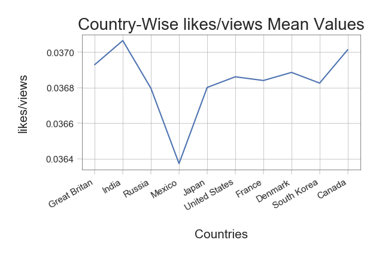

```python
MeanCompare(views_likes , 'likes/views')
```

OBSERVATION

1.India , on average, has the highest ratio of likes/views.(>0.0370) -likes/views = 0.0370 means that on average, 0.0370 of the viewers like the video.

```
2.Mexico , on average, has the lowest ratio of likes/views. (<0.0364)
```

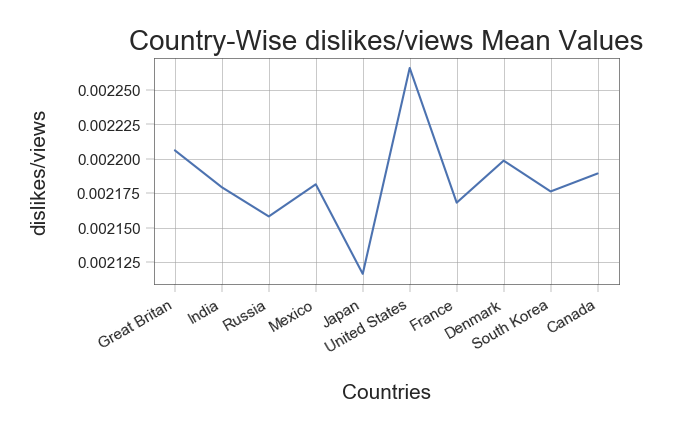

```python
MeanCompare(views_dislikes,'dislikes/views')
```

OBSERVATION

1.US , on average , has the highest ratio of dislikes/views.(>0.002250) -dislikes/views = 0.002250 means that on average, 0.002250 of the viewers dislike the video.

```
2.Japan ,on average, has the lowest ratio of dislikes/views.(<0.002125)
```

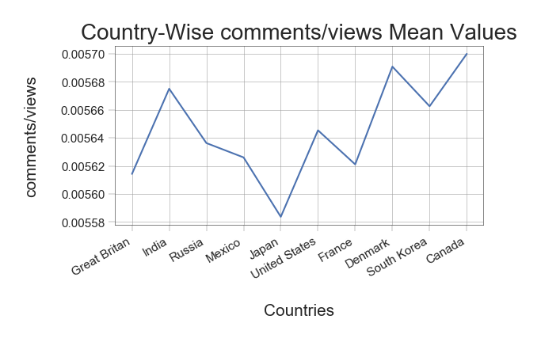

```python
MeanCompare(views_comments,'comments/views')
```

OBSERVATION

1.Canada , on average , has the highest ratio of comments/views.(0.00570)

-comments/views = 0.00570 means that on average, 0.00570 of the viewers leave a comment on the video.

2.Japan ,on average, has the lowest ratio of comments/views.(<0.00560)

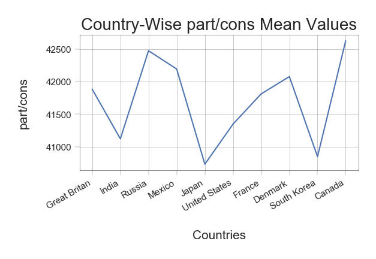

```python
MeanCompare(cons_part,'part/cons')
```

# No of Instances

```python
size=[]
for i in countries:
    select = data.loc[data['region']==i] #Selects all rows of a particular country
    total_rows = len(select.index)
    size.append(total_rows)
```

```python
size
```

```
[38916, 37352, 40739, 40451, 20523, 40949, 40724, 40840, 34567, 40881]
```

```python
K=[]
for i in range(0,len(countries)):
    K.append(i)
```

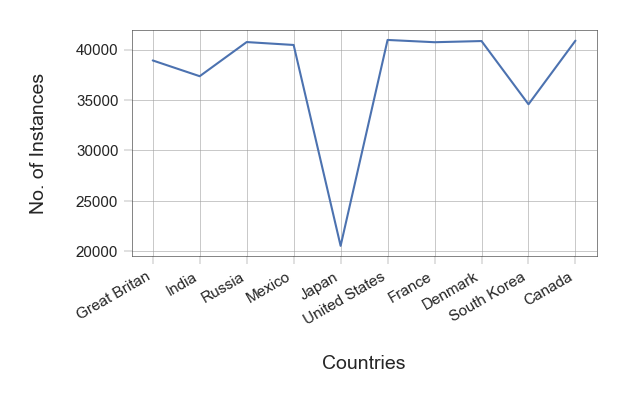

```python
plt.plot(K,size)
plt.xlabel('Countries')
plt.ylabel('No. of Instances')
plt.xticks(K,countries,rotation=30,horizontalalignment='right')
plt.show()
```

# Correlation of Attributes (Country-Wise)

```python
corr_vl=[]
corr_vd=[]
corr_vc=[]
corr_ld=[]
corr_lc=[]
corr_dc=[]

def corr(data_corr,country):
    corr_vl.append(np.corrcoef(data_corr['views'] ,data_corr['likes'])[1])
    corr_vd.append(np.corrcoef(data_corr['views'],data_corr['dislikes'])[1])
    corr_vc.append(np.corrcoef(data_corr['views'],data_corr['comment_count'])[1])
    corr_ld.append(np.corrcoef(data_corr['likes'],data_corr['dislikes'])[1])
    corr_lc.append(np.corrcoef(data_corr['likes'],data_corr['comment_count'])[1])
    corr_dc.append(np.corrcoef(data_corr['dislikes'],data_corr['comment_count'])[1])

for i in countries:
    select = data.loc[data['region']==i] #Selects all rows of a particular country
    corr(select,i)
```

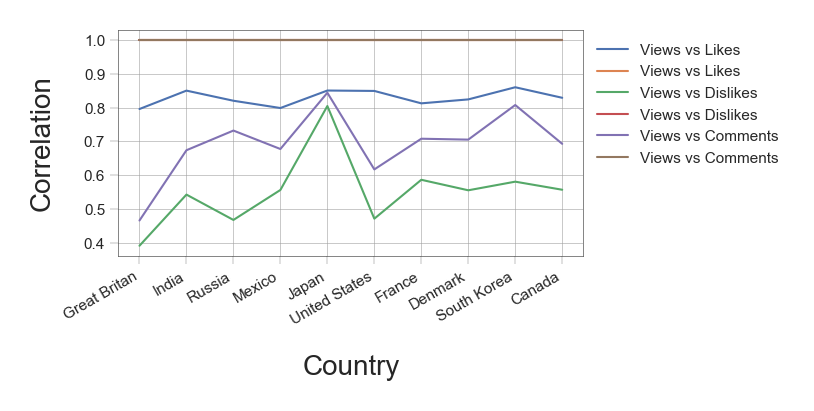

```python
plt.plot(K,corr_vl, label = "Views vs Likes")
plt.plot(K,corr_vd,label= "Views vs Dislikes")
plt.plot(K,corr_vc,label= "Views vs Comments")
plt.xlabel('Country' , fontsize=20)
plt.ylabel('Correlation',fontsize=20)

plt.xticks(K,countries,rotation=30, horizontalalignment='right')

plt.legend(bbox_to_anchor=(1.0, 1.0))
plt.show()
```

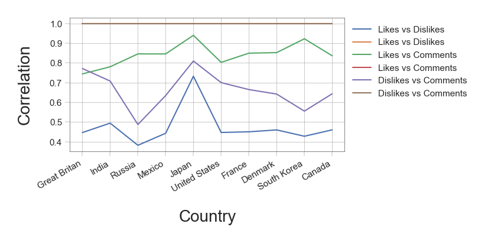

```python
plt.plot(K,corr_ld, label = "Likes vs Dislikes")
plt.plot(K,corr_lc,label= "Likes vs Comments")
plt.plot(K,corr_dc,label= "Dislikes vs Comments")
plt.xlabel('Country' , fontsize=20)
plt.ylabel('Correlation',fontsize=20)

plt.xticks(K,countries,rotation=30, horizontalalignment='right')

plt.legend(bbox_to_anchor=(1.0, 1.0))
plt.show()
```

# Comparision of Mean Values of Views,Likes,Dislikes,CommentCount ( Country-Wise)

```python
#List of Different Attributes Mean Values (Country-Wise)
views_mean=[]
likes_mean=[]
dislikes_mean=[]
comments_mean=[]

for i in countries:
    select = data.loc[data['region']==i] #Selects all rows of a particular country
    views_mean.append(select['views'].mean())
    likes_mean.append(select['likes'].mean())
    dislikes_mean.append(select['dislikes'].mean())
    comments_mean.append(select['comment_count'].mean())
```

```python
log_views_mean=[]
log_likes_mean=[]
log_dislikes_mean=[]
log_comments_mean=[]
# Let's transform all attributes with a log transformation
log_views_mean = np.log(views_mean)
log_likes_mean = np.log(likes_mean)
log_dislikes_mean = np.log(dislikes_mean)
log_comments_mean = np.log(comments_mean)
```

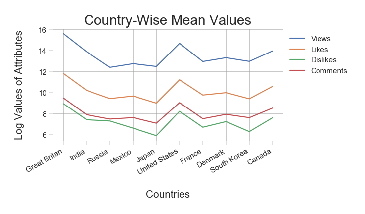

```python
plt.plot(K,log_views_mean,label='Views')
plt.plot(K,log_likes_mean,label='Likes')
plt.plot(K,log_dislikes_mean,label='Dislikes')
plt.plot(K,log_comments_mean,label='Comments')
plt.xlabel('Countries',fontsize=15)
plt.ylabel('Log Values of Attributes',fontsize=15)
plt.title('Country-Wise Mean Values',fontsize=20)
plt.xticks(K,countries,rotation=30, horizontalalignment='right')
plt.legend(bbox_to_anchor=(1.0, 1.0))
plt.show()
```